# Generalized Additive Models

###### 3è GAM

Dans ces troisièmes estimations nous nous intéressons aux effets non-linéaires bivariés où l’on suppose une corrélation entre certaines variables, ces interactions sont importantes dans les séries temporelles à double saisonnalité. Lorsque l’on inclut dans une même fonction différentes variables explicatives, on suppose que leurs effets se recoupent. Dans un premier temps nous utiliserons une fonction simple d’interaction *s($X_1$,$X_2$)* pour voir quelles variables peuvent avoir un effet bivarié, puis on cherchera à préciser cet effet. On ajoute donc au modèle n°2 existant les effets bivariés pour les variables ‘Hour’, ‘Day’ et ‘Week’ en essayant les 3 combinaisons possibles.

```r
# GAM 3 : on ajoute une fonction qui prend un effet bivarié
gam3_ID1 <- gam(JOB_DURATION ~ TAP_VERSION + s(Week, k=30, bs="ps") + s(Day, k=7, bs="ps") + s(Hour, k=24, bs="cc") + s(Hour, Day), data = df_ID1, family = gaussian)
summary(gam3_ID1)$r.sq  #0.5616
## [1] 0.5615901
summary(gam3_ID1)$s.table  # s(Hour, Day) non significatif
##                   edf    Ref.df           F     p-value
## s(Week)      3.441641  4.174854   9.9012332 0.000000000
## s(Day)       2.134411  2.555628   4.1240830 0.009774271
## s(Hour)     21.928036 22.000000 264.7467137 0.000000000
## s(Hour,Day)  1.000015  1.000030   0.2120357 0.645206073

gam3bis_ID1 <- gam(JOB_DURATION ~ TAP_VERSION + s(Week, k=30, bs="ps") + s(Day, k=7, bs="ps") + s(Hour, k=24, bs="cc") + s(Week, Day), data = df_ID1, family = gaussian)
summary(gam3bis_ID1)$r.sq  #0.5617
## [1] 0.5616596
summary(gam3bis_ID1)$s.table # s(Week, Day) non significatif
##                      edf    Ref.df            F     p-value
## s(Week)     3.441080e+00  4.174153 9.900070e+00 0.000000000
## s(Day)      2.134446e+00  2.555668 4.123968e+00 0.009772134
## s(Hour)     2.192841e+01 22.000000 2.879624e+02 0.000000000
## s(Week,Day) 1.049490e-05 27.000000 2.885171e-07 0.432102888

gam3ter_ID1 <- gam(JOB_DURATION ~ TAP_VERSION + s(Week, k=30, bs="ps") + s(Day, k=7, bs="ps") + s(Hour, k=24, bs="cc") + s(Week, Hour), data = df_ID1, family = gaussian)
summary(gam3ter_ID1)$r.sq  #0.5651
## [1] 0.5651265
summary(gam3ter_ID1)$s.table  # s(Week) non significatif mais s(Week, Hour) significatif
##                    edf    Ref.df           F      p-value
## s(Week)       1.000001  1.000001   0.2090903 6.475021e-01
## s(Day)        2.118505  2.537928   4.1278985 9.854491e-03
## s(Hour)      21.928301 22.000000 222.5610214 0.000000e+00
## s(Week,Hour) 17.121452 21.307252   2.8290703 1.484457e-05
```

Les combinaisons *s(Hour, Day)* et *s(Week, Day)* ne sont pas concluantes car non significatives, mais l’effet bivarié des variables ‘Week’ et ‘Hour’ est lui pertinent même si la fonction de la variable ‘Week’ seule n’est elle pas significative. Nous voyons aussi que la qualité du modèle ne s’est pas améliorée par rapport au modèle 2 puisque nous n’avons pu définir aucun paramètre pour l’effet bivarié. Le meilleur compromis entre ces 3 modèles estimé est donc le dernier pour lequel nous observons ci-dessous son ajustement aux valeurs réelles de Y.

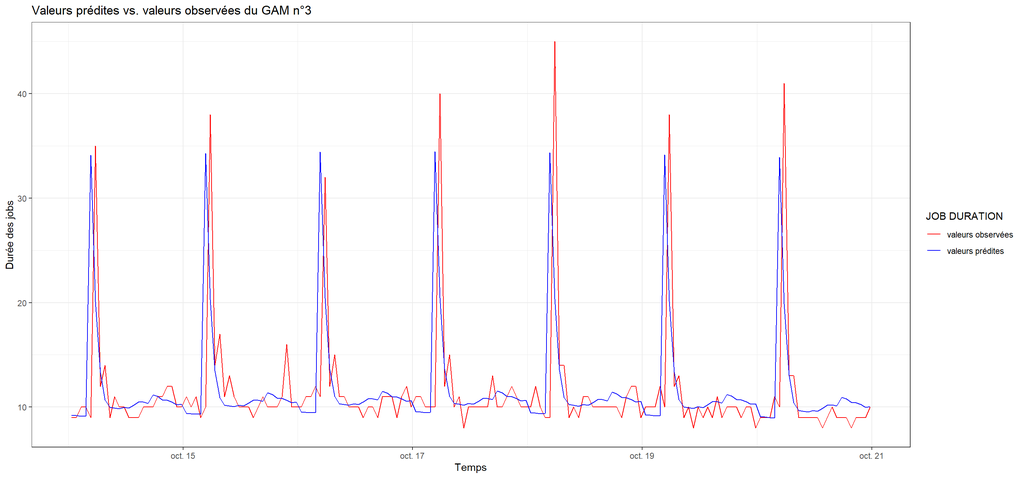

```r
# Plot du modèle conservé
fitted <- gam3ter_ID1$fitted.values
prev <- cbind(date_ID1, real_ID1, fitted)
prev <- data.frame(prev)

ggplot(data=prev[60:227,])+
  geom_line(mapping=aes(y=real_ID1,x= START_TIME,color="valeurs observées")) +
  geom_line(mapping=aes(y=fitted,x= START_TIME,color="valeurs prédites")) +
  theme_bw() +
  scale_color_manual(values = c(
    'valeurs prédites' = 'blue',
    'valeurs observées' = 'red')) +
  labs(color = 'JOB DURATION', x = "Temps", y = "Durée des jobs",
       title = "Valeurs prédites vs. valeurs observées du GAM n°3")
```

Le constat est le même que pour le modèle 2 ; les faibles volatilités de la durée des JOBS sont mal captées par le modèle. Ainsi, l’ajout de l’effet bivarié n’a pas eu d’impact significatif sur la prédiction comme on peut le constater à travers les $R^2$ et le graphique ci-dessus qui sont très proches pour les modèles 2 et 3.